# Lab06 - Built-in analyses in R

Jarad Niemi

2021-03-09

To follow along, use the lab06 code.

```r
library("tidyverse")
```

Set your working directory using Session > Set Working Directory > Choose Directory in RStudio or using the `setwd()` function. You can also save creativity.csv into your working directory if you want.

## Normal data

### Background

Suppose $Y_i\stackrel{ind}{\sim} N(\mu,\sigma^2)$. Recall that a Bayesian analysis with the default prior $p(\mu,\sigma^2) \propto 1/\sigma^2$ provides the same analysis for $\mu$ as a non-Bayesian analysis. That is

- MLE and the posterior mean/median for $\mu$ are the same
- confidence and credible intervals for $\mu$ are exactly the same

This is because the posterior for $\mu$ is
$$\mu|y \sim t_{n-1}(\overline{y}, s^2/n)$$
which means that
$$\left.\frac{\mu-\overline{y}}{s/\sqrt{n}} \right|y \sim t_{n-1}(0,1).$$
while the sampling distribution for $\overline{y}$ is such that
$$T=\frac{\overline{Y}-\mu}{S/\sqrt{n}} \sim t_{n-1}(0,1).$$

Please note the difference in these two statements is what is considered random. In the first two $\mu$ is considered random while the data which are used to calculate $\overline{y}$ and $s$ are fixed. This does not mean that a Bayesian considered the actual true value of $\mu$ to be random. Instead it means that we are expressing our uncertainty in $\mu$ through probability. In the last statement, the data are considered random which is why $\overline{Y}$ and $S$ are capitalized while $\mu$ is considered fixed.

### Manual analysis

Suppose you observe the following data

```r
set.seed(20180219)
(y <- rnorm(10, mean = 3.2, sd = 1.1)) # 3.2 and 1.1 are the population parameters
```

```
##  [1] 1.974293 4.759967 2.812764 0.758789 2.256666 4.880966 3.732871 3.929907
##  [9] 4.613458 1.649653
```

Then you can manually construct an MLE and posterior mean using `mean()`.

```r
(ybar <- mean(y))
```

```
## [1] 3.136933
```

and a 95% credible/confidence interval using

```r
n <- length(y)
s <- sd(y)

ybar + c(-1,1)*qt(.975, df = n-1)*s/sqrt(n)
```

```
## [1] 2.099208 4.174659
```

### Built-in analysis

You can use the `t.test()` function to perform this for you.

```r
t.test(y)
```

```
##
##  One Sample t-test
##
## data:  y
## t = 6.8383, df = 9, p-value = 7.572e-05
## alternative hypothesis: true mean is not equal to 0
## 95 percent confidence interval:
##  2.099208 4.174659
## sample estimates:
## mean of x
##  3.136933
```

You can extract the estimates and confidence/credible intervals, but first you need to know how to access the appropriate objects within the t-test object.

```r
tt <- t.test(y)
names(tt)
```

```
##  [1] "statistic"   "parameter"   "p.value"     "conf.int"    "estimate"
##  [6] "null.value"  "stderr"      "alternative" "method"      "data.name"
```

```r
str(tt)
```

```
## List of 10
##  $ statistic  : Named num 6.84
##   ..- attr(*, "names")= chr "t"
##  $ parameter  : Named num 9
##   ..- attr(*, "names")= chr "df"
##  $ p.value    : num 7.57e-05
##  $ conf.int   : num [1:2] 2.1 4.17
##   ..- attr(*, "conf.level")= num 0.95
##  $ estimate   : Named num 3.14
##   ..- attr(*, "names")= chr "mean of x"
##  $ null.value : Named num 0
##   ..- attr(*, "names")= chr "mean"
##  $ stderr     : num 0.459
##  $ alternative: chr "two.sided"
##  $ method     : chr "One Sample t-test"
##  $ data.name  : chr "y"
##  - attr(*, "class")= chr "htest"
```

It isn’t always obvious what object we want and thus we often need to just look at all of them until we figure out which ones we need. In this case, `conf.int` seems like a good guess for the confidence/credible intervals. It turns out that `estimate` will gives us the MLE and posterior mean/median.

```r
tt$estimate
```

```
## mean of x
##  3.136933
```

```r
tt$conf.int
```

```
## [1] 2.099208 4.174659
## attr(,"conf.level")
## [1] 0.95
```

#### Modifying arguments

We can also change the default argument values to

- change the type of hypothesis test
- change the null value
- change the confidence level

Suppose we wanted to test $H_0:\mu\ge 1$ vs $H_a:\mu < 1$ at a signficance level of 0.9 and/or we wanted to construct a 90% one-sided lower confidence interval.

```r
t.test(y, alternative = "less",    mu = 1,  conf.level = 0.9)
```

```
##
##  One Sample t-test
##
## data:  y
## t = 4.6583, df = 9, p-value = 0.9994
## alternative hypothesis: true mean is less than 1
## 90 percent confidence interval:
##      -Inf 3.771374
## sample estimates:
## mean of x
##  3.136933
```

Suppose we wanted to test $H_0:\mu\le -1$ vs $H_a:\mu > -1$ at a signficance level of 0.99 and/or we wanted to construct a 99% one-sided upper confidence interval.

```r
t.test(y, alternative = "greater", mu = -1, conf.level = 0.99)
```

```
##
##  One Sample t-test
##
## data:  y
## t = 9.0182, df = 9, p-value = 4.199e-06
## alternative hypothesis: true mean is greater than -1
## 99 percent confidence interval:
##  1.842647      Inf
## sample estimates:
## mean of x
##  3.136933
```

#### Activity

Using the following data, compare the point estimate and confidence/credible intervals obtained using the `t.test()` function to estimates and intervals you create yourself.

If you have more time, try to play around with the function arguments to create one-sided confidence intervals, change the null hypothesis value, and change the confidence/significance level.

```r
set.seed(1)
y <- rnorm(1001, mean = 256, sd = 34.6)
```

**Click for solution**

```r
t.test(y)
```

```
##
##  One Sample t-test
##
## data:  y
## t = 225.84, df = 1000, p-value < 2.2e-16
## alternative hypothesis: true mean is not equal to 0
## 95 percent confidence interval:
##  253.4154 257.8578
## sample estimates:
## mean of x
##  255.6366
```

```r
mean(y)
```

```
## [1] 255.6366
```

```r
mean(y) + c(-1,1)*qt(.975, df = length(y)-1)*sd(y)/sqrt(length(y))
```

```
## [1] 253.4154 257.8578
```

## Binomial data

### Bayesian analysis

Let $Y\sim Bin(n,\theta)$. Recall that our default prior for $\theta$ is $\theta \sim Be(1,1)$, which is equivalent to a $Unif(0,1)$ prior. The posterior under this prior is $\theta|y \sim Be(1+y,1+n-y)$. In order to perform this analysis, we simply use the beta distribution in R.

Suppose you observe 9 successes out of 13 attempts.

```r
a <- b <- 1
n <- 13
y <- 9
```

The posterior is

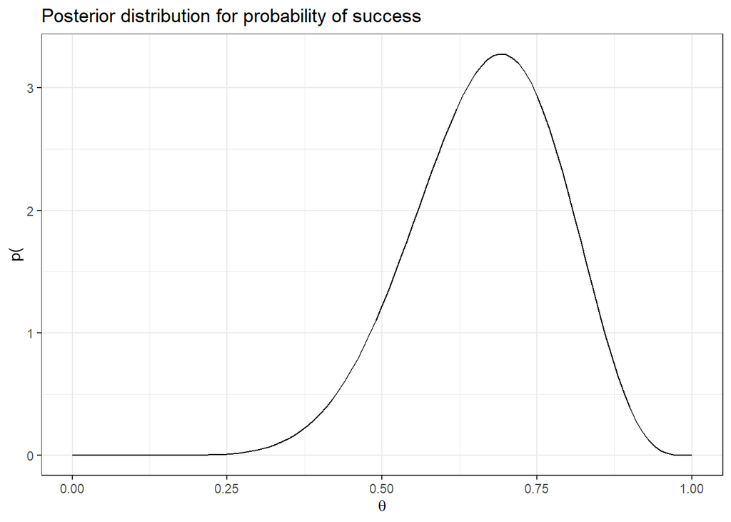

```r
ggplot(data.frame(x=c(0,1)), aes(x=x)) +
  stat_function(fun = dbeta,
                args = list(shape1 = a+y,
                            shape2 = b+n-y)) +
  labs(x = expression(theta),
       y = paste(expression("p(",theta,"|y)")),
       title = "Posterior distribution for probability of success") +
  theme_bw()
```

The posterior expectation is

```r
(a+y)/(a+b+n)
```

```
## [1] 0.6666667
```

A 95% equal-tail credible interval is

```r
qbeta(c(.025,.975), a+y, b+n-y)
```

```
## [1] 0.4189647 0.8724016
```

The probability that $\theta$ is greater than 0.5, i.e. $P(\theta>0.5|y)$ is

```r
1-pbeta(0.5, a+y, b+n-y)
```

```
## [1] 0.9102173
```

#### Jeffreys prior activity

An alternative prior is called Jeffreys prior and it corresponds to a Be(0.5,0.5) prior. Suppose you observed 17 successes out of 20 attempts and you are willing to assume independence and a common probability of success. Use Jeffreys prior on this probability of success to do the following

- Plot the posterior for the true probability of success
- Calculate the posterior median for the true probability of success
- Calculate a one-sided upper 95% credible interval for the true probability of success
- Calculate the probability that the true probability of success is greater than 0.9.

**Click for solution**

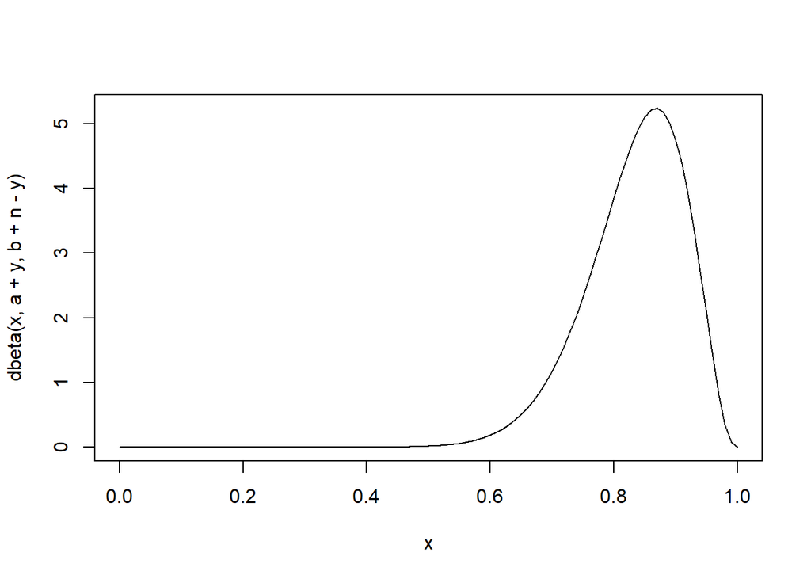

```r
a <- b <- 0.5
n <- 20
y <- 17
curve(dbeta(x, a+y, b+n-y))
```

```r
qbeta(0.5, a+y, b+n-y)
```

```
## [1] 0.8439957
```

```r
c(qbeta(0.05, a+y, b+n-y), 1)
```

```
## [1] 0.6863196 1.0000000
```

```r
1-pbeta(0.9, a+y, b+n-y)
```

```
## [1] 0.2137305
```

### Non-Bayesian analyses when n is small

To perform non-Bayesian analyses when n is small, use the `binom.test` function. This will calculate pvalues and confidence intervals (based on inverting hypothesis tests).

Suppose you observe 9 successes out of 13 attempts.

```r
n <- 13
y <- 9
binom.test(y, n)
```

```
##
##  Exact binomial test
##
## data:  y and n
## number of successes = 9, number of trials = 13, p-value = 0.2668
## alternative hypothesis: true probability of success is not equal to 0.5
## 95 percent confidence interval:
##  0.3857383 0.9090796
## sample estimates:
## probability of success
##              0.6923077
```

This is equivalent to calculating the probability of observing y equal to 0, 1, 2, 3, 4, 9, 10, 11, 12, 13 if $\theta$ is 0.5.

```r
sum(dbinom(c(0:4,9:13), size = n, prob = 0.5))
```

```
## [1] 0.2668457
```

```r
ci <- binom.test(y,n)$conf.int
binom.test(y, n, p=ci[2])$p.value # This one matches exactly
```

```
## [1] 0.025
```

```r
binom.test(y, n, p=ci[1])$p.value # This one is close
```

```
## [1] 0.04124282
```

#### binom.test Activity

Suppose you observe 11 successes out of 12 attempts. Calculate a pvalue for the two-sided test that $\theta=0.5$ and construct a 95% confidence interval.

**Click for solution**

```r
binom.test(11,12)
```

```
##
##  Exact binomial test
##
## data:  11 and 12
## number of successes = 11, number of trials = 12, p-value = 0.006348
## alternative hypothesis: true probability of success is not equal to 0.5
## 95 percent confidence interval:
##  0.6152038 0.9978924
## sample estimates:
## probability of success
##              0.9166667
```

### Non-Bayesian analyses when n is large (and p is not close to 0 or 1)

If you observe 78 successes out of 100 attempts, then you can use the `prop.test()` function to generate a number of statistics automatically based on the CLT.

```r
n <- 100
y <- 78
prop.test(y,n)
```

```
##
##  1-sample proportions test with continuity correction
##
## data:  y out of n, null probability 0.5
## X-squared = 30.25, df = 1, p-value = 3.798e-08
## alternative hypothesis: true p is not equal to 0.5
## 95 percent confidence interval:
##  0.6838686 0.8541734
## sample estimates:
##    p
## 0.78
```

The estimate is

```r
pt <- prop.test(y,n)
pt$estimate
```

```
##    p
## 0.78
```

An approximate 95% confidence interval is

```r
pt$conf.int
```

```
## [1] 0.6838686 0.8541734
## attr(,"conf.level")
## [1] 0.95
```

We can construct this ourself using the following formula

```r
p <- y/n
p + c(-1,1)*qnorm(.975)*sqrt(p*(1-p)/n)
```

```
## [1] 0.6988092 0.8611908
```

The results don’t quite match because `prop.test` uses the continuity correction (which is the appropriate thing to do).

```r
prop.test(y, n, correct = FALSE)
```

```
##
##  1-sample proportions test without continuity correction
##
## data:  y out of n, null probability 0.5
## X-squared = 31.36, df = 1, p-value = 2.144e-08
## alternative hypothesis: true p is not equal to 0.5
## 95 percent confidence interval:
##  0.6892965 0.8499872
## sample estimates:
##    p
## 0.78
```

Unfortunately, the results still don’t quite match. It turns out there is a large literature on how to do this and the suggestions are to either 1) use Wilson’s interval (which is what `prop.test` does) or to use 2) Jeffreys, i.e. a Beta(1/2,1/2) prior in a Bayesian analysis.

#### Activity

Suppose you observed 694 success out of 934 attempts. Compute an approximate 95% equal-tail confidence interval using `prop.test` and compare this to a 95% equal-tail confidence interval you construct using the Central Limit Theorem.

**Click for solution**

```r
y <- 694
n <- 934
prop.test(y, n)$conf.int
```

```
## [1] 0.7135099 0.7705425
## attr(,"conf.level")
## [1] 0.95
```

```r
p <- y/n
p + c(-1,1)*qnorm(.975)*sqrt(p*(1-p)/n)
```

```
## [1] 0.7150178 0.7710636
```

```r
# If you turn off the continuity correction, you will get closer
prop.test(y, n, correct = FALSE)$conf.int
```

```
## [1] 0.7140620 0.7700283
## attr(,"conf.level")
## [1] 0.95
```

If you really want to figure out what the function is doing, you can look at the function by just typing `prop.test` and hitting enter.

#### Activity

Suppose you observe 0 success out of 77 attempts. Compare 95% confidence intervals given by `prop.test` and `binom.test` to an interval you construct based on the CLT and to 95% credible intervals.

**Click for solution**

So this is a bit of a trick question since there were 0 successes. When you run `prop.test` and `binom.test` you are given one-sided confidence intervals. The CLT interval doesn’t exist since the standard error is zero. The appropriate credible interval to use is a one-sided interval.

```r
y <- 0
n <- 77
prop.test(y, n)$conf.int
```

```
## [1] 0.00000000 0.05921002
## attr(,"conf.level")
## [1] 0.95
```

```r
binom.test(y, n)$conf.int
```

```
## [1] 0.00000000 0.04677807
## attr(,"conf.level")
## [1] 0.95
```

```r
qbeta(c(0,.95), 1+y, 1+n-y)
```

[output not shown]

## Reading data from files

First, let’s write some data to a file.

```r
set.seed(20180220)
# Generate some simulated data
n <- 100
d <- data.frame(rep = 1:n,
                response = sample(c("Yes","No"), n, replace=TRUE, prob = c(.2,.8)),
                measurement = rnorm(n, mean = 55, sd = 12))

# Write it to a file
# make sure you have set your working directory to someplace where you want this
# file to be written
write.csv(d,
          file = "data.csv",
          row.names = FALSE)
```

Alternatively, you could use the `write_csv()` function in the [readr](https://cran.r-project.org/web/packages/readr/index.html) package.

```r
install.packages("readr")
library("readr")
write_csv(d, path = "data.csv")
```

Now let’s read this data back in.

```r
my_data <- read.csv("data.csv")
```

If you want to delete the file, you can run the following

```r
if (file.exists("data.csv")) file.remove("data.csv")
```

```
## [1] TRUE
```

Take a look at the data to make sure it looks correct:

```r
head(my_data)
```

```
##   rep response measurement
## 1   1       No    49.16525
## 2   2       No    66.62369
## 3   3       No    35.14872
## 4   4       No    61.15329
## 5   5       No    61.34038
## 6   6       No    53.79730
```

```r
str(my_data)
```

```
## 'data.frame':    100 obs. of  3 variables:
##  $ rep        : int  1 2 3 4 5 6 7 8 9 10 ...
##  $ response   : chr  "No" "No" "No" "No" ...
##  $ measurement: num  49.2 66.6 35.1 61.2 61.3 ...
```

### Binomial data

To use `prop.test()` and `binom.test()`, you need to calculate the number of successes and the number of attempts.

```r
y <- sum(my_data$response == "Yes")
n <- length(my_data$response)
prop.test(y, n)
```

```
##
##  1-sample proportions test with continuity correction
##
## data:  y out of n, null probability 0.5
## X-squared = 32.49, df = 1, p-value = 1.198e-08
## alternative hypothesis: true p is not equal to 0.5
## 95 percent confidence interval:
##  0.1375032 0.3052597
## sample estimates:
##    p
## 0.21
```

```r
binom.test(y, n)
```

```
##
##  Exact binomial test
##
## data:  y and n
## number of successes = 21, number of trials = 100, p-value = 4.337e-09
## alternative hypothesis: true probability of success is not equal to 0.5
## 95 percent confidence interval:
##  0.1349437 0.3029154
## sample estimates:
## probability of success
##                   0.21
```

### Normal data

To analyze the normal data, you can just use `t.test()` directly.

```r
t.test(my_data$measurement)
```

```
##
##  One Sample t-test
##
## data:  my_data$measurement
## t = 42.956, df = 99, p-value < 2.2e-16
## alternative hypothesis: true mean is not equal to 0
## 95 percent confidence interval:
##  50.91322 55.84453
## sample estimates:
## mean of x
##  53.37888
```

#### Online activity

Read in the data at creativity.csv and then construct confidence/credible intervals for mean creativity score for both the Intrinsic and Extrinsic groups.

**Click for solution**

There are a variety of ways to do this. I will construct two new data frames to contain the Intrinsic and Extrinsic data and then construct the intervals.

```r
creativity <- read.csv("http://www.jarad.me/courses/stat587Eng/labs/lab06/creativity.csv")

intrinsic_score <- creativity$Score[creativity$Treatment == "Intrinsic"]
extrinsic_score <- creativity$Score[creativity$Treatment == "Extrinsic"]
t.test(intrinsic_score)
```

```
##
##  One Sample t-test
##
## data:  intrinsic_score
## t = 21.941, df = 23, p-value < 2.2e-16
## alternative hypothesis: true mean is not equal to 0
## 95 percent confidence interval:
##  18.00869 21.75798
## sample estimates:
## mean of x
##  19.88333
```

```r
t.test(extrinsic_score)
```

```
##
##  One Sample t-test
##
## data:  extrinsic_score
## t = 14.37, df = 22, p-value = 1.16e-12
## alternative hypothesis: true mean is not equal to 0
## 95 percent confidence interval:
##  13.46774 18.01052
## sample estimates:
## mean of x
##  15.73913
```

```r
# Using the `subset` command which subsets the data.frame
intrinsic <- subset(creativity, Treatment == "Intrinsic")
extrinsic <- subset(creativity, Treatment == "Extrinsic")

t.test(intrinsic$Score)
```

```
##
##  One Sample t-test
##
## data:  intrinsic$Score
## t = 21.941, df = 23, p-value < 2.2e-16
## alternative hypothesis: true mean is not equal to 0
## 95 percent confidence interval:
##  18.00869 21.75798
## sample estimates:
## mean of x
##  19.88333
```

```r
t.test(extrinsic$Score)
```

```
##
##  One Sample t-test
##
## data:  extrinsic$Score
## t = 14.37, df = 22, p-value = 1.16e-12
## alternative hypothesis: true mean is not equal to 0
## 95 percent confidence interval:
##  13.46774 18.01052
## sample estimates:
## mean of x
##  15.73913
```

```r
# Another way to subset uses the dplyr package
# This will be prettier when you have a long sequence of commands
library(dplyr)
intrinsic <- creativity %>% filter(Treatment == "Intrinsic")
extrinsic <- creativity %>% filter(Treatment == "Extrinsic")
```

If you want to find out more about these data, take a look at the help file for `case0101` in the [Sleuth3](https://cran.r-project.org/web/packages/Sleuth3/index.html) package.

```r
install.packages("Sleuth3")
library("Sleuth3")
?case0101
```